# DataMining en Ciencias. Trabajo Práctico 1: Procesamiento de los datos

Freiman Sebastián sebafreiman@gmail.com, Louzau Estefanía eplouz@gmail.com, Michalla Bárbara barbaramichalla@gmail.com, Ríos Leandro Martín rios.leandromartin@gmail.com

13 de septiembre de 2016

El objetivo de esta primera parte del trabajo práctico es conocer los datos con que van a trabajar, realizar un análisis exploratorio y detectar y solucionar varios problemas que presentan los datos.

El trabajo realizado se organiza en las siguientes secciones.

## Preparación de los datos

A continuación se describen las técnicas y herramientas utilizadas para preparar los datos que se pretende analizar.

La herramienta principal en la que se apoya este trabajo es [R](https://www.r-project.org/), utilizándose a través del [RStudio](https://www.rstudio.com/) y varios de los paquetes que provee [CRAN](https://cran.r-project.org/) y el propio software.

### Configuración del entorno

Para comenzar, se setea el directorio de trabajo, comunmente denominado *Working Directory* de donde se obtendrán los datasets y donde se almacenarán los resultados parciales obtenidos.

A efectos prácticos, se descarga el mismo al directorio de trabajo.

### Análisis de los datos

Se realiza una previsualización de los datos y se revisa con qué formato R interpretó a los mismos.

```
## 'data.frame':    3462 obs. of  65 variables:
##  $ Nr      : int  6 9 16 21 26 29 45 49 50 51 ...
##  $ Rmag    : num  25 25 24.2 25.2 25.5 ...
##  $ e.Rmag  : num  0.097 0.181 0.054 0.128 0.112 0.056 0.257 0.217 0.098 0.097 ...
##  $ ApDRmag : num  0.935 -0.135 0.821 0.639 -1.588 ...
##  $ mumax   : num  24.2 25.3 23.5 24.9 24.9 ...
##  $ Mcz     : num  0.832 0.927 1.202 0.912 0.848 ...
##  $ e.Mcz   : num  0.036 0.122 0.037 0.177 0.067 0.183 0.174 0.147 0.052 0.057 ...
##  $ MCzml   : num  1.4 0.864 1.217 0.776 1.33 ...
##  $ chi2red : num  0.64 0.41 0.92 0.39 1.45 0.52 1.31 1.84 1.03 0.55 ...
##  $ UjMAG   : num  -17.7 -18.3 -19.8 -17.8 -17.7 ...
##  $ e.UjMAG : num  0.14 0.22 0.14 0.17 0.42 0.16 0.3 0.44 0.15 0.16 ...
##  $ BjMAG   : num  -17.5 17.9 -19.9 -17.4 -18.4 ...
##  $ e.BjMAG : num  0.25 0.55 0.14 0.31 0.83 1.37 1.94 1.81 0.15 0.19 ...
##  $ VjMAG   : num  -17.8 -18.2 -20.4 -17.7 -19.4 ...
```

[output cut: 51 more lines]

Se aprecia que los datos corresponden mayormente a variables numéricas, dado que se incluyen estimadores del tamaño de la galaxia, de su corrimiento al rojo y datos y flujos y magnitudes absolutas obtenidas a diferentes longitudes de onda.

Pero una de las variables, `e.W420FE` fue importada como tipo caracter.

```
##  chr [1:3462] "3.85E-03" "3.19E-03" "4.11E-03" "2.70E-03" ...
```

Por el tipo de nomenclatura utilizada, se puede deducir que se trata de un error y que debería ser considerada como variable numérica.

Se intuye que la causa del problema podría ser la notación científica esta especificada con la letra mayúscula “E”, dado que comparada con la variable `VFD`, se observa que la misma presenta la notación científica con la letra “e” minúscula.

```
##  num [1:3462] 1.73e-02 3.93e-03 1.88e-02 9.67e-03 3.85e-05 3.55e-03 5.04e-03 1.20e-04 8.59e-03 1.46e-02 ...
```

Por lo tanto se procede a intentar convertirla al tipo numérico.

```
## Warning: NAs introducidos por coerción
```

Se obtiene un Warning que indica que hubo valores que no pudo convertir, los cuales dejó como `NA` o nulos.

Se imprime un resumen para identificar cuál fue el volumen de registros que no consiguió convertir y cuáles son los valores de dichos registros.

```
##
## FALSE  TRUE
##  3319   143
```

```
##   [1] "3  3.100E-03" "3  3.089E-03" "2  1.296E-02" "3  2.858E-03"
##   [5] "4  2.855E-03" "2  2.452E-02" "5  3.528E-03" "3  3.510E-03"
##   [9] "3  1.961E-02" "5  3.780E-03" "4  2.387E-02" "4  3.050E-03"
##  [13] "2  2.358E-02" "4  1.651E-02" "2  2.539E-02" "3  1.769E-02"
##  [17] "4  2.895E-03" "3  3.554E-03" "3  1.264E-02" "2  2.717E-02"
##  [21] "3  3.325E-03" "3  2.924E-03" "3  2.937E-03" "3  5.001E-03"
##  [25] "3  4.780E-03" "4  2.840E-03" "4  3.076E-03" "3  3.039E-03"
##  [29] "3  3.594E-03" "3  1.809E-02" "3  3.171E-03" "3  2.813E-03"
##  [33] "3  3.745E-03" "3  3.603E-03" "5  3.105E-03" "3  2.865E-03"
##  [37] "4  3.412E-03" "3  2.876E-03" "2  2.482E-02" "3  3.127E-03"
##  [41] "4  3.826E-03" "3  3.026E-03" "3  5.249E-03" "2  2.309E-02"
##  [45] "3  3.732E-03" "2  2.779E-02" "3  2.803E-03" "3  2.878E-03"
##  [49] "3  3.848E-03" "3  3.246E-03" "3  9.861E-03" "4  3.337E-03"
##  [53] "3  3.297E-03" "3  1.653E-02" "4  3.020E-03" "3  3.339E-03"
##  [57] "3  2.891E-03" "2  2.414E-02" "3  3.448E-03" "3  2.714E-03"
```

[output cut: 21 more lines]

Por simple inspección se puede apreciar que los 143 datos que no fueron convertidos a “numeric”, poseen el siguiente patrón en su estructura.

> `dígito + 2 espacios + numero en notación exponencial`

El equipo consensuó que por el rango esperado de la variable, se debe tomar como criterio válido que la porción correspondiente al llamado `numero en notación exponencial` es el correcto valor de la misma.

Se aplica la función `strsplit` para dividir el campo utilizando los espacios centrales. La función devuelve una lista con el `dígito` en la primera posición y el `número_notación_exponencial` en la segunda. Para obtener el segundo elemento de esa lista, dado que no es recomendable utilizar ciclos FOR en el lenguage R, se utiliza la función `sapply`.

La misma proviene de la familia de funciones:

- apply
- lapply
- sapply

Una vez obtenido el dato para la variable, se repite el procedimiento de conversión a `numeric`, del cual ya no se obtienen errores o warnings.

Por lo tanto se procede a reemplazar los datos originales de la variable por los datos transformados, para poder operarlo correctamente en los sucesivos análisis, comprobándose que ahora los datos son del tipo `numeric` y no se observan valores `NA`.

```
##  num [1:3462] 0.00385 0.00319 0.00411 0.0027 0.00371 0.00302 0.00288 0.00426 0.00384 0.00283 ...
```

```
##
## FALSE
##  3462
```

## Tratamiento de Datos Faltantes

Con el objetivo de identificar la presencia de valores extremos o datos faltantes, se realizan controles mediante la observación de tablas y gráficos exploratorios que ayuden a vizualizarlos.

En primer lugar se verifica la presencia de datos faltantes en cualquiera de las variables del dataset.

```
##
##  FALSE   TRUE
## 224980     50
```

```
## [1] "VnMAG"    "e.VbMAG"  "S280MAG"  "e.S280MA"
```

El equipo considera que la cantidad de casos con datos faltantes es despreciable, por lo que se procede a eliminar dichas observaciones para asegurar que se trabajará con datos completos y sin rellenar.

Se comprueba que luego de retirados dichos casos, el dataset obtenido ya no posee datos faltantes:

```
##
##  FALSE
## 223470
```

## Tratamiento de Outliers

Se comienza analizando las variables `Rmag` y `e.Rmag`, que representan la magnitud total en la banda R y su error de medición.

[output not shown]

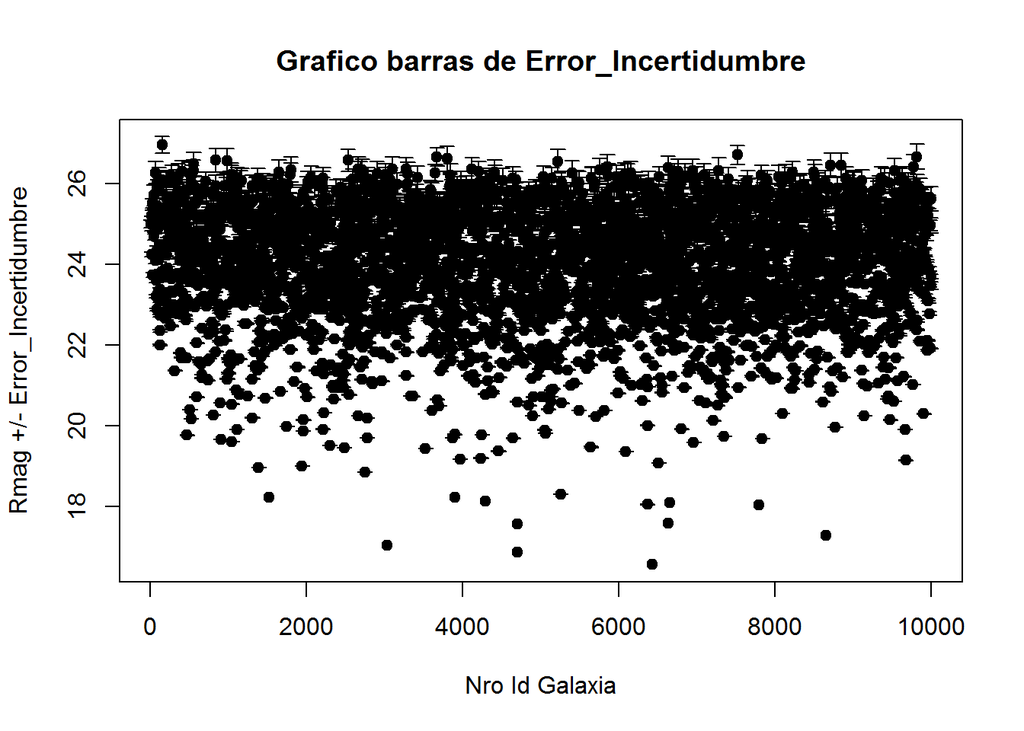

Como puede apreciarse en el gráfico, resulta muy complicado visualizar o identificar la presencia de valores extremos a través de él.

Pasemos a analizar la segunda variable de interés, `ApDRmag`, que representa la diferencia entre la magnitud total y la magnitud de apertura medidas en la banda R. Es un estimador del tamaño de una galaxia. Un valor de cero indica que es una fuente puntual de luz. Los valores negativos se generan por errores de medición.

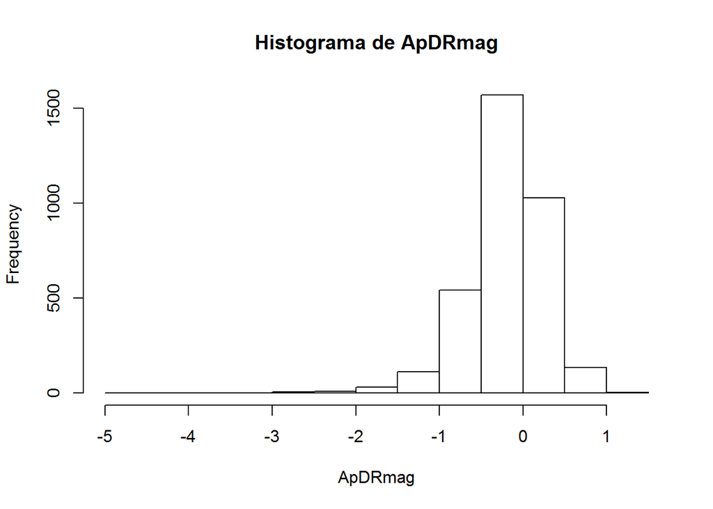

[ desde acá para mi no va. como el histograma da valores negativos, esos son los que hay q sacar!!! BM]

El problema con los histogramas que son los rangos o la cantidad de clases, los cuales son deteminados de forma empírica. Otro inconveniente es el ancho de clase suele ser una variable a tener en consideración. Pero debe hacerse especial hincapie en el rango desde y hasta donde se desea visualizar. En general es preferible los gráficos de densidad de kernel, los cuales son una función continua y pueden someterse a la una derivada.

Realizamos un gráfico simple de densidad de kernel. Son muy recomendables cuando se tienen muchos registros.

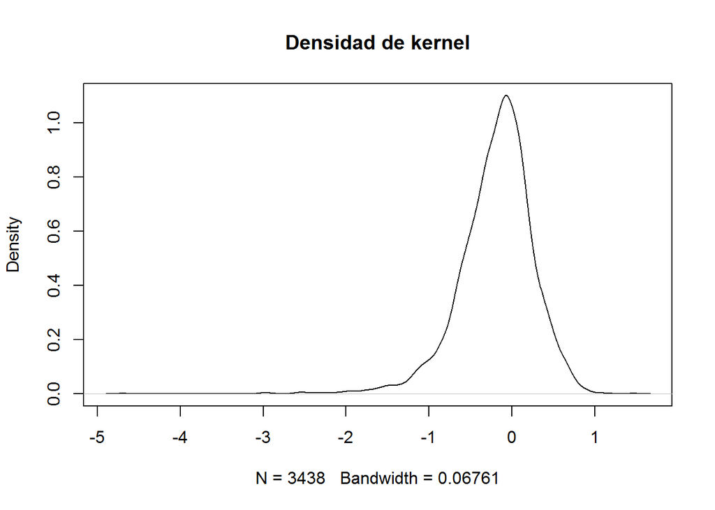

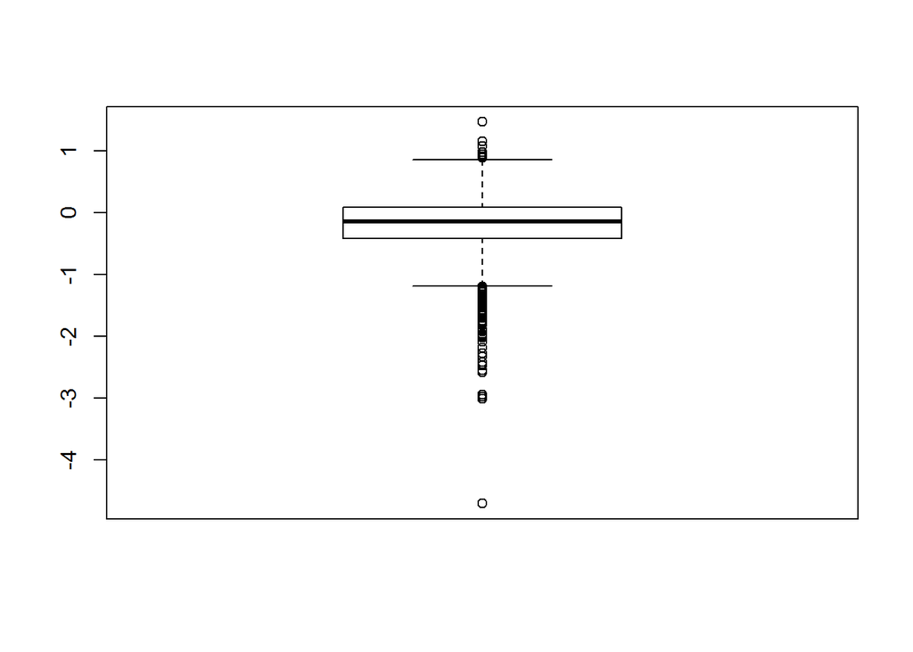

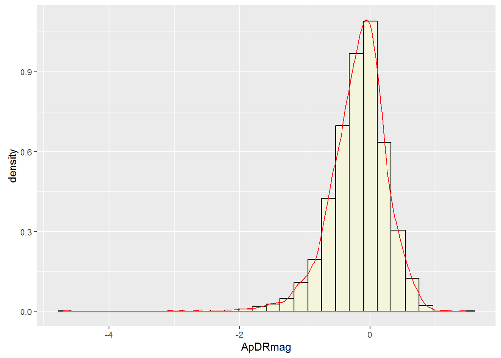

como se puede apreciar, la librería ggplot es mas vistosa. La palabra clave “aes” esta relacionada con la estetica, que hace referencia a las variables que se quieren representar. Luego +geom_histogram() seria la forma, es decir como represento los datos. El signo + es por la primer capa. En este caso la segunda capa esta referida +geom_density()

Se debe destacar la nomenclatura utilizada: x = ApDRmag en vez de: x = glx$ApDRmag De esta forma el creador de la libreria ggplot, Hadley Wickham, es consistente con su filosofía “Tidy data” paper publicado en “The Journal of Statistical Software, vol. 59, 2014”

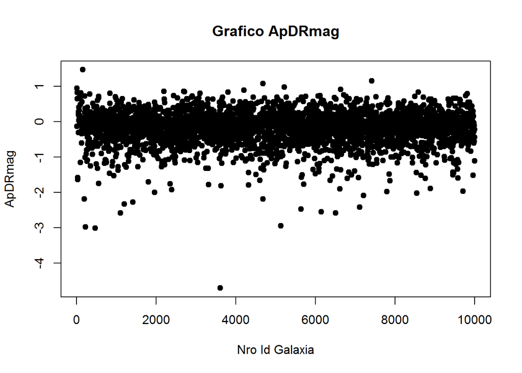

Se procede a eliminar la fila que tieneese punto anomalo

```
## [1] 1175
```

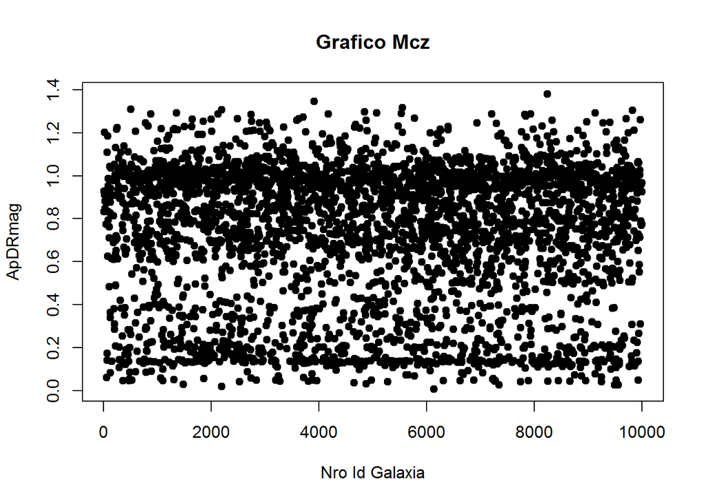

## Otros gráficos y técnicas de diagnóstico.

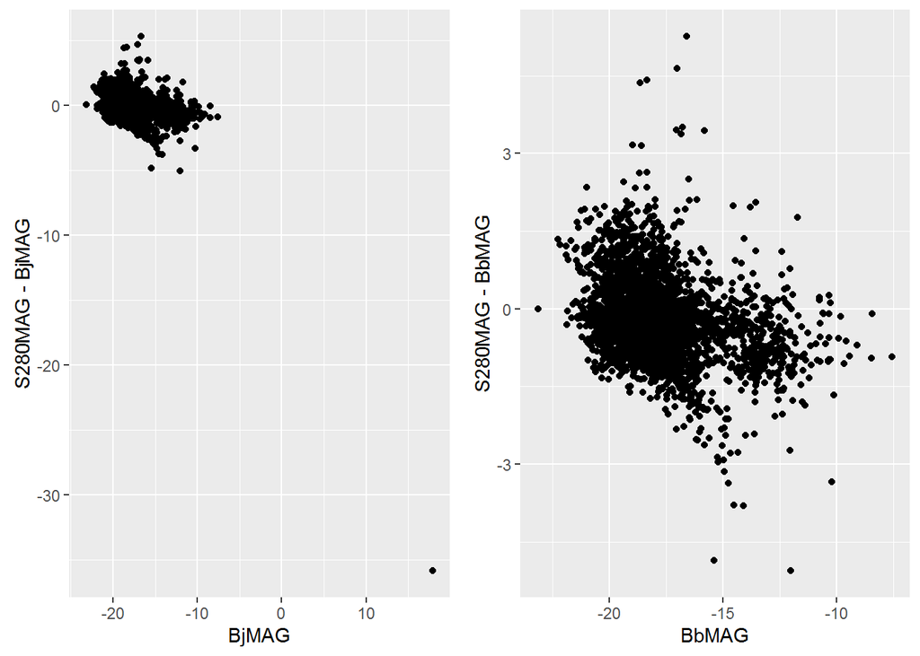

```
## [1] 2
```

```
## [1] 17.86
```

Eliminando el outlier y volvemos a graficar

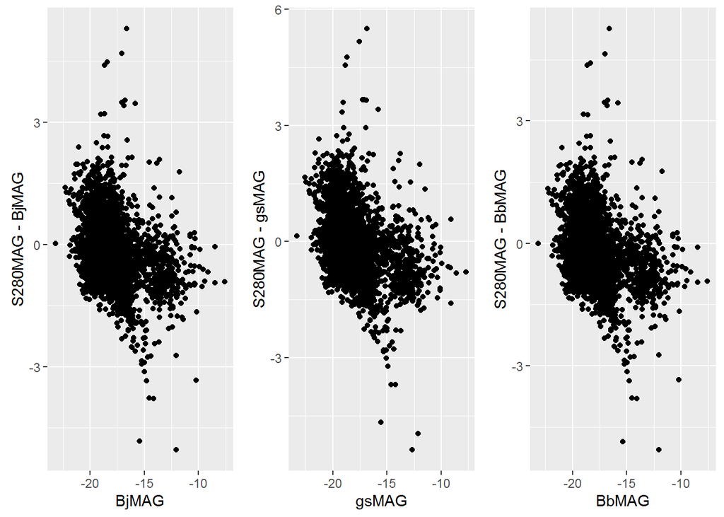

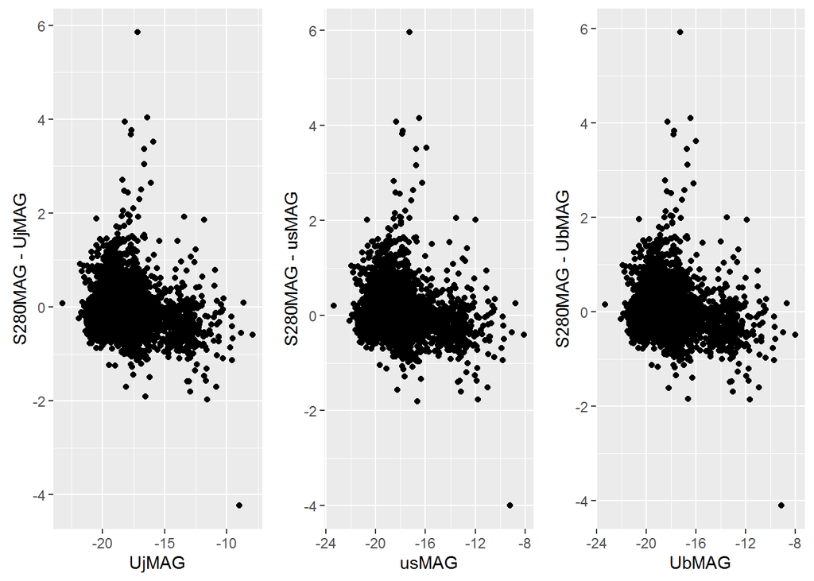

```
## [1] 2882
```

```
## [1] 2882
```

```
## [1] 2432
```

```
## [1] 2432
```

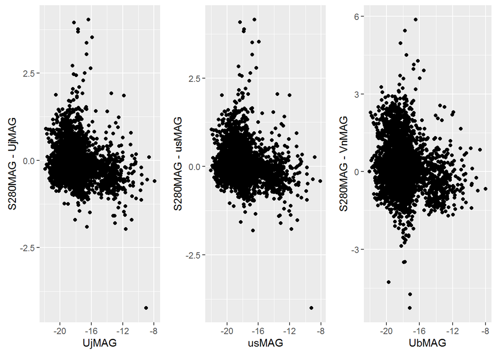

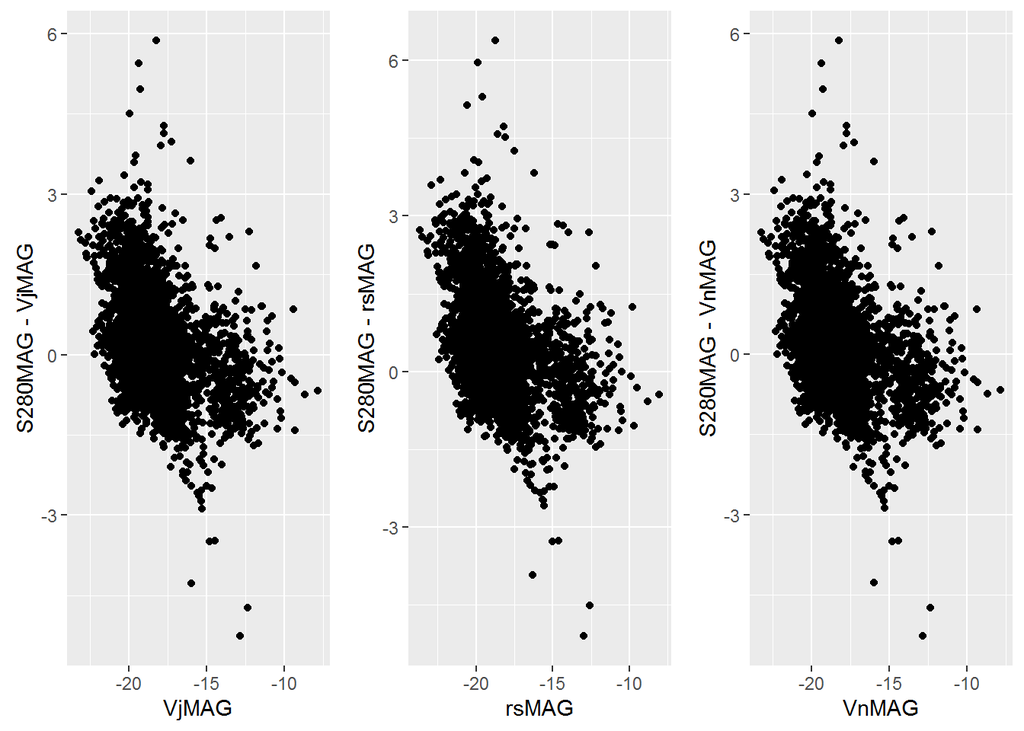

## Correlaciones entre las variables

```
##    UjMAG  BjMAG  VjMAG  usMAG  gsMAG  rsMAG  UbMAG  BbMAG  VnMAG S280MAG
## 1 -17.67 -17.54 -17.76 -17.83 -17.60 -17.97 -17.76 -17.53 -17.76  -18.22
## 3 -19.75 -19.91 -20.41 -19.87 -20.05 -20.71 -19.82 -19.89 -20.40  -19.77
## 4 -17.83 -17.39 -17.67 -17.98 -17.47 -17.89 -17.92 -17.38 -17.67  -18.12
## 5 -17.69 -18.40 -19.37 -17.81 -18.69 -19.88 -17.76 -18.35 -19.37  -13.93
## 6 -19.22 -18.11 -18.70 -19.34 -18.27 -19.05 -19.30 -18.08 -18.69  -19.18
## 7 -17.09 -16.06 -16.23 -17.26 -16.11 -16.39 -17.19 -16.05 -16.22  -17.81
```

```
##    UjMAG  BjMAG  VjMAG  usMAG  gsMAG  rsMAG  UbMAG  BbMAG  VnMAG S280MAG
## 1 -17.67 -17.54 -17.76 -17.83 -17.60 -17.97 -17.76 -17.53 -17.76  -18.22
## 3 -19.75 -19.91 -20.41 -19.87 -20.05 -20.71 -19.82 -19.89 -20.40  -19.77
## 4 -17.83 -17.39 -17.67 -17.98 -17.47 -17.89 -17.92 -17.38 -17.67  -18.12
## 5 -17.69 -18.40 -19.37 -17.81 -18.69 -19.88 -17.76 -18.35 -19.37  -13.93
## 6 -19.22 -18.11 -18.70 -19.34 -18.27 -19.05 -19.30 -18.08 -18.69  -19.18
## 7 -17.09 -16.06 -16.23 -17.26 -16.11 -16.39 -17.19 -16.05 -16.22  -17.81
```

```
##    UjMAG  BjMAG  VjMAG  usMAG  gsMAG  rsMAG  UbMAG  BbMAG  VnMAG S280MAG
## 1 -17.67 -17.54 -17.76 -17.83 -17.60 -17.97 -17.76 -17.53 -17.76  -18.22
## 3 -19.75 -19.91 -20.41 -19.87 -20.05 -20.71 -19.82 -19.89 -20.40  -19.77
## 4 -17.83 -17.39 -17.67 -17.98 -17.47 -17.89 -17.92 -17.38 -17.67  -18.12
## 5 -17.69 -18.40 -19.37 -17.81 -18.69 -19.88 -17.76 -18.35 -19.37  -13.93
## 6 -19.22 -18.11 -18.70 -19.34 -18.27 -19.05 -19.30 -18.08 -18.69  -19.18
## 7 -17.09 -16.06 -16.23 -17.26 -16.11 -16.39 -17.19 -16.05 -16.22  -17.81
##   UjMAG_Norm BjMAG_Norm VjMAG_Norm usMAG_Norm gsMAG_Norm rsMAG_Norm
## 1      -0.55      -0.68      -0.46      -0.39      -0.62      -0.25
## 3      -0.02       0.14       0.64       0.10       0.28       0.94
## 4      -0.29      -0.73      -0.45      -0.14      -0.65      -0.23
## 5       3.76       4.47       5.44       3.88       4.76       5.95
## 6       0.04      -1.07      -0.48       0.16      -0.91      -0.13
## 7      -0.72      -1.75      -1.58      -0.55      -1.70      -1.42
##   UbMAG_Norm BbMAG_Norm VnMAG_Norm
## 1      -0.46      -0.69      -0.46
## 3       0.05       0.12       0.63
## 4      -0.20      -0.74      -0.45
## 5       3.83       4.42       5.44
## 6       0.12      -1.10      -0.49
## 7      -0.62      -1.76      -1.59
```